# Time of day and day of week effect the frequency but not location of theft from vehicles in San Francisco in summer 2014

Jon

24 January 2016

This report looks at how the time of day and day of week affected thefts from vehicles in San Francisco during the summer of 2014. In this analysis, we see there is a clear trend of theft from vehicles peaking in the evening and dipping early morning. When looking at how crime varied throughout the week, there is a slight peaking during the weekend starting on Friday. The same data was then plotted by location to see if weekday vs weekend or daytime vs nighttime had an effect on the location of the crime. These plots did not show any clear trends.

## Dataset Overview

The data used for this analysis was original sources from the SF OpenData portal https://data.sfgov.org/Public-Safety/SFPD-Incidents-from-1-January-2003/tmnf-yvry which contains data collected from the SFPD Crime Incident Reporting system, the subsetted data for summer 2014 was sourced from course material for the CourseraData Science at Scale specialization https://github.com/uwescience/datasci_course_materials/blob/master/assignment6/sanfrancisco_incidents_summer_2014.csv.

SFPD Crime Incident Reporting uses several categories to report a theft from vehicles, these are.

- GRAND THEFT FROM LOCKED AUTO
- GRAND THEFT FROM UNLOCKED AUTO
- ATTEMPTED THEFT FROM LOCKED VEHICLE
- PETTY THEFT FROM UNLOCKED AUTO
- PETTY THEFT FROM LOCKED AUTO

For this investigation, all categories are combined and investigated togeather.

# Day of Week

This first plot shows the Theft from vehicles for each day of the week.

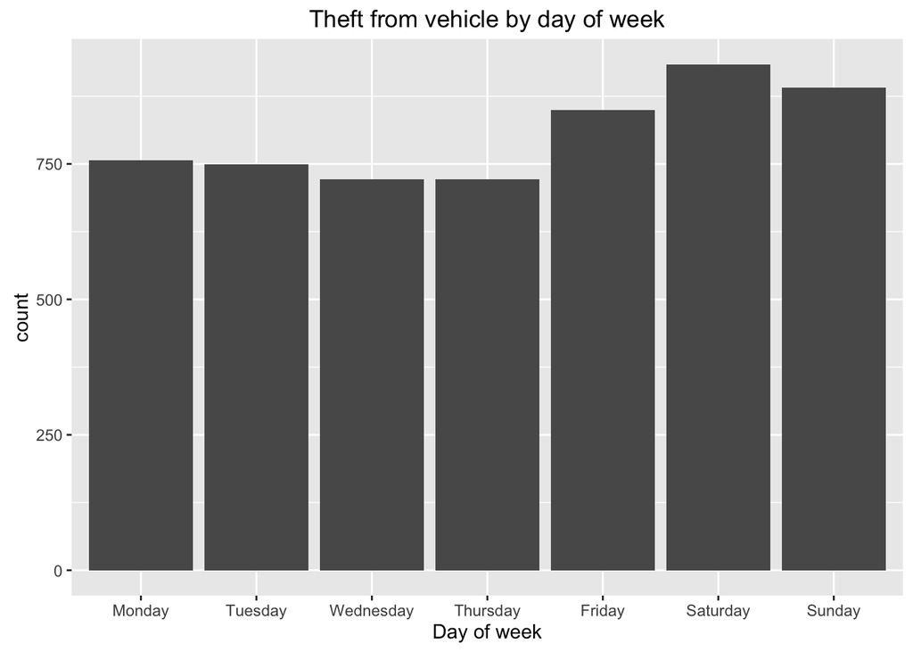

# Time of Day

This next plot shows the Theft from vehicles for each time of the day. To simplify this graphic, each report of a crime was rounded to its nearest hour.

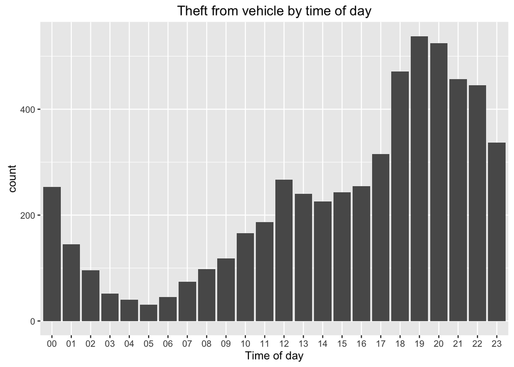

This plot shows a clear trend of the crime rate increasing throught the day with a peak at 7 pm and a minimum at 5 am. The difference in crime rate from the minimum at 5 am to 7 pm is over 13 times.

# Location of crime

## Weekend vs Weekday

This next plot shows the location of each crime plotted on a map of San Fransisco, the color of the pin indicates if the crime was committed on the weekend or not.

[figure not shown]

## Day Time vs Night Time

This next plot also shows the location of each crime plotted on a map of San Fransisco, the color of the pin indicates if the crime was committed at night. To determine night the midpoint for the date range of July 15th, 2014 was used to look up the Civil Twilight hours for San Francisco from http://www.timeanddate.com/sun/usa/san-francisco?month=7&year=2014. This was 5:29am - 9:02pm, so nighttime was considered to be 9pm >= x <= 5.

[figure not shown]

The spread of crime location does not appear to be affected by the night vs day time split.

# Reproducibility

This document was produced using R and R Markdown. The raw R Markdown document includes all the code to manipulate the data and generate the plots can be viewed at https://github.com/jonprice/datasciencecoursera/blob/master/communicatingdatascienceresults/assignment1/report.Rmd.